# Covid-19 in Netherlands

AS2019340

2022-10-06

# **Abstract**

Corona virus disease (COVID-19) is an infectious disease caused by the SARS-CoV-2 virus.A novel corona virus (CoV) named ‘2019-nCoV’ or ‘2019 novel corona virus’ or ‘COVID-19’ by the World Health Organization (WHO) is in charge of the current outbreak of pneumonia that began at the beginning of December 2019 near in Wuhan City, Hubei Province, China [1–4]. COVID-19 is a pathogenic virus. The COVID-19 pandemic is not over yet. As individuals we can do our part in keeping others safe by following the rules suggested by the government and WHO.

In Netherlands, from 3 January 2020 to 3:45pm CEST, 6 October 2022, there have been 8,441,351 confirmed cases of COVID-19 with 22,663 deaths, reported to WHO. As of 10 September 2022, a total of 36,105,753 vaccine doses have been administered.

# **1) Introduction about Netherlands**

The Netherlands is a constituent country located in Western Europe.With a population of 17.7 million people, all living within a total area of roughly 41,800 km2 (16,100 sq mi)—of which the land area is 33,500 km2 (12,900 sq mi)—the Netherlands is the 16th most densely populated country in the world and the second-most densely populated country in the European Union. Nevertheless, it is the world’s second-largest exporter of food and agricultural products by value, owing to its fertile soil, mild climate, intensive agriculture, and inventiveness.The Netherlands ranks among the highest in international indices of press freedom,[35] economic freedom,[36] human development and quality of life, as well as happiness.

## *Health Service in Netherlands*

In 2016, the Netherlands maintained its number one position at the top of the annual Euro health consumer index (EHCI), which compares healthcare systems in Europe, scoring 916 of a maximum 1,000 points.The Netherlands was ranked first in a study in 2009 comparing the health care systems of the United States, Australia, Canada, Germany and New Zealand. Patients have a great degree of freedom from where to buy their health insurance, to where they get their healthcare service.Healthcare decisions are being made in a dialogue between the patients and healthcare professionals.

## *Covid-19 in Netherlands*

The virus reached the Netherlands on 27 February 2020, when its first COVID-19 case was confirmed in Tilburg.[5] It involved a 56-year-old Dutchman who had arrived in the Netherlands from Italy, where the COVID-19 pandemic seemed to enter Europe. As of 31 January 2021, there are 978,475 confirmed cases of infections and 13,998 confirmed deaths.[6] The first death occurred on 6 March, when an 86-year-old patient died in Rotterdam.[7]

## *Actions Taken by Dutch Government*

On 23 January 2021, as the government imposed a nationwide 9:00 p.m. curfew in a context of emergence of the British variant, the worst riots in 40 years broke out across the country.Since the end of November 2021, the SARS-CoV-2 Omicron variant is spreading in parts of Europe (i.e. UK, Denmark and France). The number of registered new infections has risen strongly. There is a lockdown in the Netherlands from 19 December 2021 to (at least) 14 January 2022.

## *Location of Netherlands*

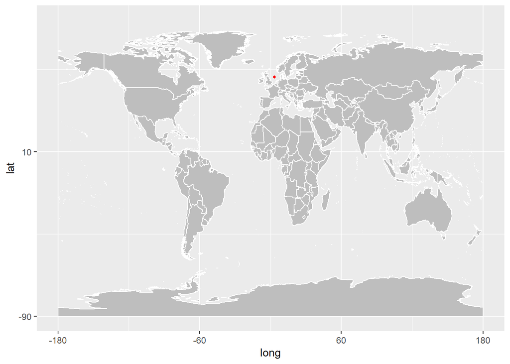

# **2) Exploratory Data Analysis**

## *A summery of the Netherlands Covid-19 data set.*

```
      date              province           country               lat
 Min.   :2020-01-22   Length:13260       Length:13260       Min.   :12.17
 1st Qu.:2020-08-29   Class :character   Class :character   1st Qu.:12.18
 Median :2021-04-07   Mode  :character   Mode  :character   Median :12.52
 Mean   :2021-04-07                                         Mean   :21.41
 3rd Qu.:2021-11-14                                         3rd Qu.:18.04
 Max.   :2022-06-23                                         Max.   :52.13

      long             type               cases             uid
 Min.   :-69.968   Length:13260       Min.   :     0   Min.   :528.0
 1st Qu.:-68.990   Class :character   1st Qu.:     0   1st Qu.:531.0
 Median :-68.239   Mode  :character   Median :     0   Median :533.0
 Mean   :-52.992                      Mean   :   627   Mean   :532.2
 3rd Qu.:-63.055                      3rd Qu.:     8   3rd Qu.:534.0
 Max.   :  5.291                      Max.   :380388   Max.   :535.0
                                      NA's   :14
     iso2               iso3               code3       combined_key
 Length:13260       Length:13260       Min.   :528.0   Length:13260
 Class :character   Class :character   1st Qu.:531.0   Class :character
 Mode  :character   Mode  :character   Median :533.0   Mode  :character
                                       Mean   :532.2
                                       3rd Qu.:534.0
                                       Max.   :535.0

   population       continent_name     continent_code
 Min.   :   26221   Length:13260       Length:13260
 1st Qu.:   42882   Class :character   Class :character
 Median :  106766   Mode  :character   Mode  :character
 Mean   : 3494968
 3rd Qu.:  164100
 Max.   :17134873
```

## *Confirmed Covid-19 Cases in Netherlands*

```
        date province     country     lat     long      type cases uid iso2
1 2020-01-22    Aruba Netherlands 12.5211 -69.9683 confirmed     0 533   AW
2 2020-01-23    Aruba Netherlands 12.5211 -69.9683 confirmed     0 533   AW
3 2020-01-24    Aruba Netherlands 12.5211 -69.9683 confirmed     0 533   AW
4 2020-01-25    Aruba Netherlands 12.5211 -69.9683 confirmed     0 533   AW
5 2020-01-26    Aruba Netherlands 12.5211 -69.9683 confirmed     0 533   AW
6 2020-01-27    Aruba Netherlands 12.5211 -69.9683 confirmed     0 533   AW
  iso3 code3       combined_key population continent_name continent_code
1  ABW   533 Aruba, Netherlands     106766  North America             NA
2  ABW   533 Aruba, Netherlands     106766  North America             NA
3  ABW   533 Aruba, Netherlands     106766  North America             NA
4  ABW   533 Aruba, Netherlands     106766  North America             NA
5  ABW   533 Aruba, Netherlands     106766  North America             NA
6  ABW   533 Aruba, Netherlands     106766  North America             NA
```

```
[1] 8252995
```

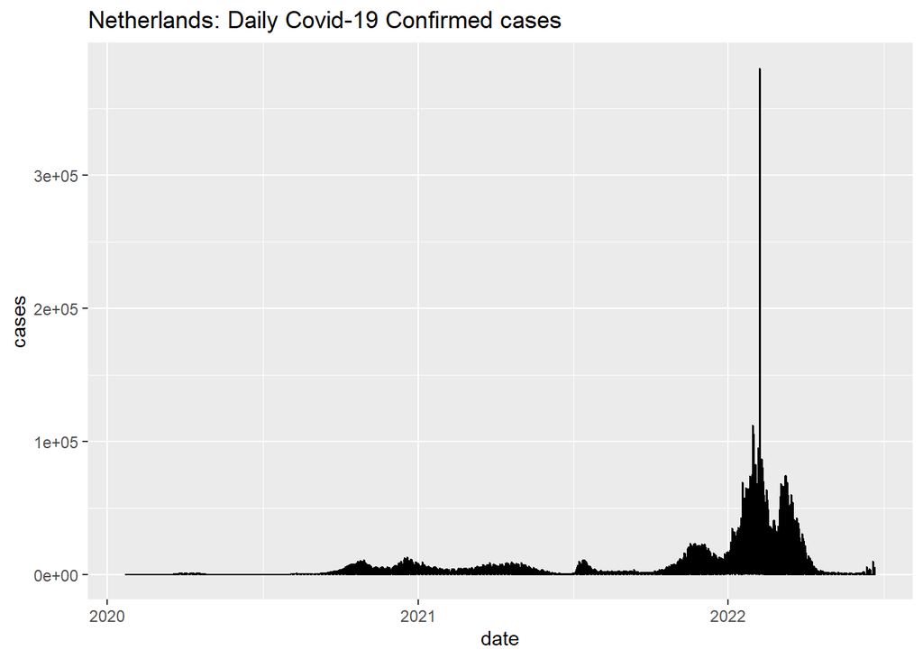

According to the above graph in the beginning of the corona virus spreading over the world the number of corona confirmed cases are in minor value but the number of confirm cases is rapidly increased since 2022 January.It shows that the most of Covid-19 confirm cases are in 2022 year.The virus is rapidly spread in this year first half.But it is decreased in the middle of the year to very low value of confirmed cases.

## *Covid-19 Deaths in Netherlands*

```
        date province     country     lat     long  type cases uid iso2 iso3
1 2020-01-22    Aruba Netherlands 12.5211 -69.9683 death     0 533   AW  ABW
2 2020-01-23    Aruba Netherlands 12.5211 -69.9683 death     0 533   AW  ABW
3 2020-01-24    Aruba Netherlands 12.5211 -69.9683 death     0 533   AW  ABW
4 2020-01-25    Aruba Netherlands 12.5211 -69.9683 death     0 533   AW  ABW
5 2020-01-26    Aruba Netherlands 12.5211 -69.9683 death     0 533   AW  ABW
6 2020-01-27    Aruba Netherlands 12.5211 -69.9683 death     0 533   AW  ABW
  code3       combined_key population continent_name continent_code
1   533 Aruba, Netherlands     106766  North America             NA
2   533 Aruba, Netherlands     106766  North America             NA
3   533 Aruba, Netherlands     106766  North America             NA
4   533 Aruba, Netherlands     106766  North America             NA
5   533 Aruba, Netherlands     106766  North America             NA
6   533 Aruba, Netherlands     106766  North America             NA
```

```
[1] 22972
```

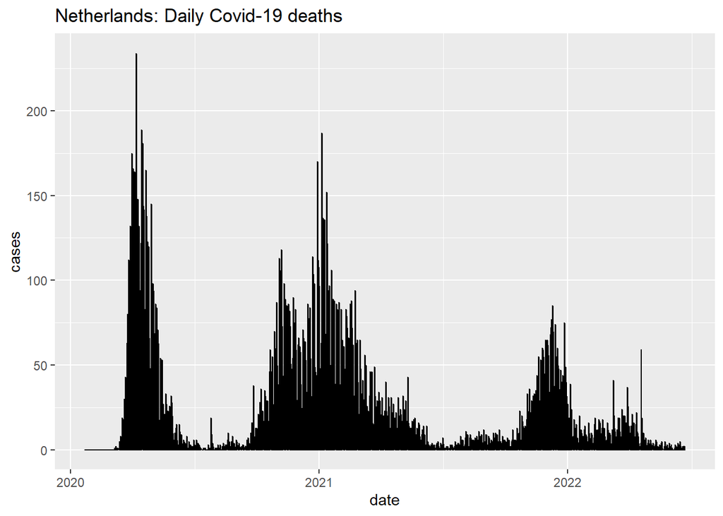

Deaths variation shows highest increased and decreased in every year.Most number of deaths shows in 2021 but the highest daily value of death is in 2020.According to the graph it shows that the covid-19 deaths are decreased in the 2022 year.The total value of deaths is 22972.

## *Covid-19 Recoveries in Netherlands*

```
        date province     country     lat     long     type cases uid iso2 iso3
1 2020-01-22    Aruba Netherlands 12.5211 -69.9683 recovery     0 533   AW  ABW
2 2020-01-23    Aruba Netherlands 12.5211 -69.9683 recovery     0 533   AW  ABW
3 2020-01-24    Aruba Netherlands 12.5211 -69.9683 recovery     0 533   AW  ABW
4 2020-01-25    Aruba Netherlands 12.5211 -69.9683 recovery     0 533   AW  ABW
5 2020-01-26    Aruba Netherlands 12.5211 -69.9683 recovery     0 533   AW  ABW
6 2020-01-27    Aruba Netherlands 12.5211 -69.9683 recovery     0 533   AW  ABW
  code3       combined_key population continent_name continent_code
1   533 Aruba, Netherlands     106766  North America             NA
2   533 Aruba, Netherlands     106766  North America             NA
3   533 Aruba, Netherlands     106766  North America             NA
4   533 Aruba, Netherlands     106766  North America             NA
5   533 Aruba, Netherlands     106766  North America             NA
6   533 Aruba, Netherlands     106766  North America             NA
```

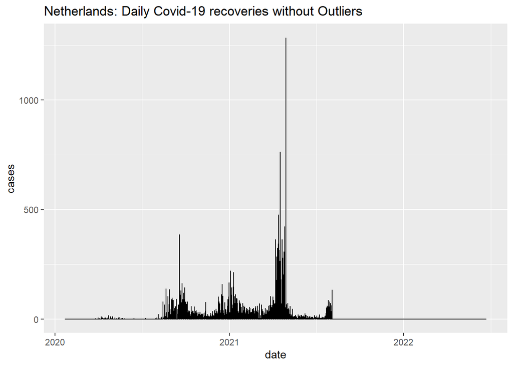

## *Covid-19 Active Cases in Netherlands*

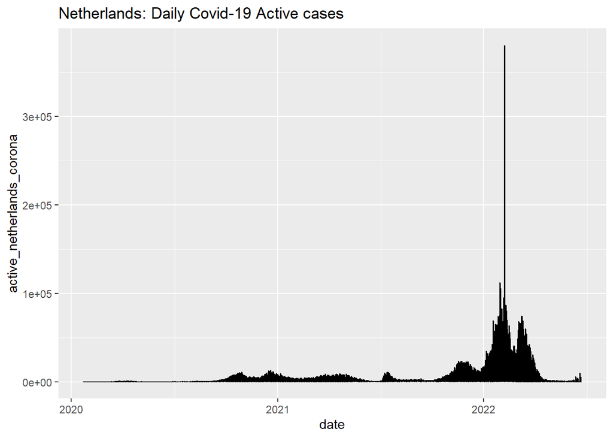

We can see large number of Covid-19 active cases in 2022 firs 6 months. The active cases shows a increasing nearly 2021 september and it shows decreasing nearly after 2022 april.

## *Covid-19 Confirmed,Death & Recovery Cases in Netherlands*

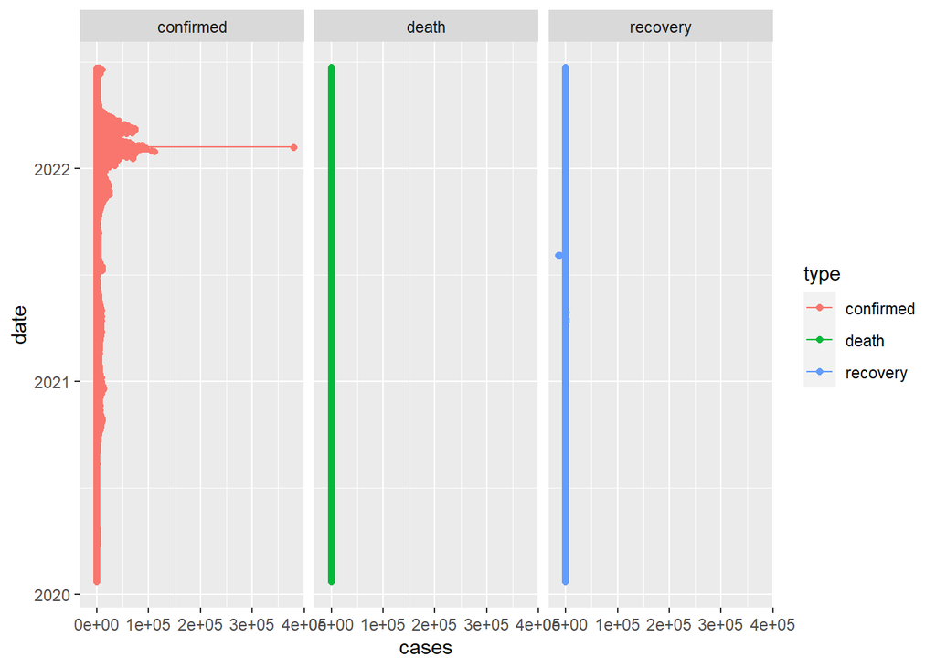

# **2) Comparison between the neighborhood countries**

```
  [1] "Canada"                           "United Kingdom"
  [3] "China"                            "Netherlands"
  [5] "Australia"                        "New Zealand"
  [7] "Denmark"                          "France"
  [9] "Afghanistan"                      "Albania"
 [11] "Algeria"                          "Andorra"
 [13] "Angola"                           "Antarctica"
 [15] "Antigua and Barbuda"              "Argentina"
 [17] "Armenia"                          "Austria"
 [19] "Azerbaijan"                       "Bahamas"
 [21] "Bahrain"                          "Bangladesh"
 [23] "Barbados"                         "Belarus"
 [25] "Belgium"                          "Belize"
 [27] "Benin"                            "Bhutan"
 [29] "Bolivia"                          "Bosnia and Herzegovina"
```

[output cut: 85 more lines]

## *Summary of comparison between neighborhood countries*

```
      date              province           country               lat
 Min.   :2020-01-22   Length:50388       Length:50388       Min.   :-21.12
 1st Qu.:2020-08-29   Class :character   Class :character   1st Qu.:-12.83
 Median :2021-04-07   Mode  :character   Mode  :character   Median : 14.64
 Mean   :2021-04-07                                         Mean   : 15.06
 3rd Qu.:2021-11-14                                         3rd Qu.: 46.23
 Max.   :2022-06-23                                         Max.   : 52.13
      long             type               cases               uid
 Min.   :-178.12   Length:50388       Min.   :-3659260   Min.   : 56.0
 1st Qu.: -63.05   Class :character   1st Qu.:       0   1st Qu.:258.0
 Median : -56.32   Mode  :character   Median :       0   Median :531.0
 Mean   : -19.37                      Mean   :    1412   Mean   :460.6
 3rd Qu.:  10.45                      3rd Qu.:       3   3rd Qu.:638.0
 Max.   : 165.62                      Max.   :  527487   Max.   :876.0
     iso2               iso3               code3       combined_key
 Length:50388       Length:50388       Min.   : 56.0   Length:50388
 Class :character   Class :character   1st Qu.:258.0   Class :character
 Mode  :character   Mode  :character   Median :531.0   Mode  :character
                                       Mean   :460.6
                                       3rd Qu.:638.0
                                       Max.   :876.0
   population       continent_name     continent_code
 Min.   :    5795   Length:50388       Length:50388
 1st Qu.:   38659   Class :character   Class :character
 Median :  280904   Mode  :character   Mode  :character
 Mean   : 9526323
 3rd Qu.:  895308
 Max.   :83783945
```

## *Input missing values*

```
      date              province           country               lat
 Min.   :2020-01-22   Length:50388       Length:50388       Min.   :-21.12
 1st Qu.:2020-08-29   Class :character   Class :character   1st Qu.:-12.83
 Median :2021-04-07   Mode  :character   Mode  :character   Median : 14.64
 Mean   :2021-04-07                                         Mean   : 15.06
 3rd Qu.:2021-11-14                                         3rd Qu.: 46.23
 Max.   :2022-06-23                                         Max.   : 52.13

      long             type               cases             uid
 Min.   :-178.12   Length:50388       Min.   :     0   Min.   : 56.0
 1st Qu.: -63.05   Class :character   1st Qu.:     0   1st Qu.:258.0
 Median : -56.32   Mode  :character   Median :     0   Median :531.0
 Mean   : -19.37                      Mean   :  1508   Mean   :460.6
 3rd Qu.:  10.45                      3rd Qu.:     3   3rd Qu.:638.0
 Max.   : 165.62                      Max.   :527487   Max.   :876.0
                                      NA's   :132
     iso2               iso3               code3       combined_key
 Length:50388       Length:50388       Min.   : 56.0   Length:50388
 Class :character   Class :character   1st Qu.:258.0   Class :character
 Mode  :character   Mode  :character   Median :531.0   Mode  :character
                                       Mean   :460.6
                                       3rd Qu.:638.0
                                       Max.   :876.0

   population       continent_name     continent_code
 Min.   :    5795   Length:50388       Length:50388
 1st Qu.:   38659   Class :character   Class :character
 Median :  280904   Mode  :character   Mode  :character
 Mean   : 9526323
 3rd Qu.:  895308
 Max.   :83783945
```

```
  [1]  4687  5241  5933  5940  8127  8131  8135  8144  8812  9402 10286 11170
 [13] 11567 12054 14061 14296 14338 14945 15583 15590 17014 17739 17960 17976
 [25] 19004 20091 20949 21653 21996 22596 23058 23976 24015 24800 25960 26582
 [37] 28362 28365 28381 28387 28412 28421 28422 28447 28576 28668 28726 28773
 [49] 28805 29038 29141 29160 29613 31378 31534 31557 31647 32349 32874 34723
 [61] 37706 39015 39020 39078 39123 39174 39184 39276 39436 39481 39646 40342
 [73] 41226 42110 42994 43878 44762 45646 46530 47414 48298 49182 49620 49636
 [85] 49650 49662 49669 49673 49675 49676 49678 49679 49680 49683 49685 49686
 [97] 49687 49690 49692 49694 49697 49699 49700 49704 49706 49707 49709 49711
[109] 49714 49715 49716 49722 49725 49732 49741 49744 49751 49766 49767 49774
[121] 49980 49994 50008 50015 50022 50030 50036 50043 50050 50058 50064 50066
```

## *Comparison of death cases between Neighborhood Countries & Netherlands*

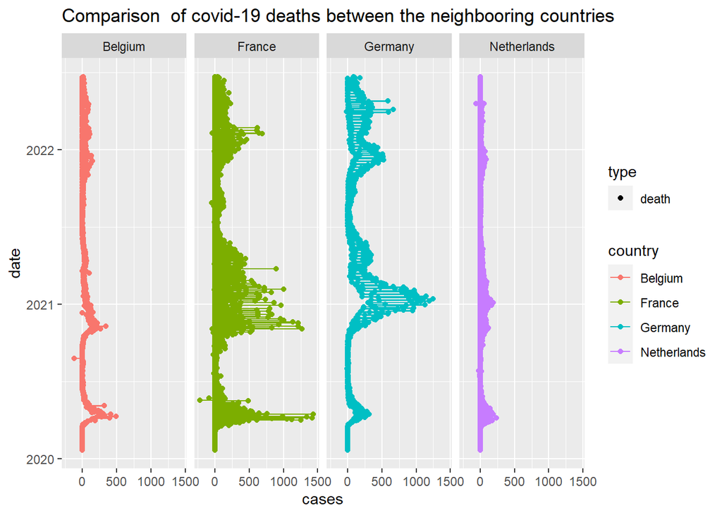

We can see most of deaths in France and Germany. Netherlands Covid-19 deaths are lower than neighborhood countries according to this figure.